# Tutorial: RICH-data

This is a basic tutorial for the `RICH_data` python package.

## Setup and configuration

### Import package

First, import the `RICH_data` package

```python
import RICH_data
```

### Get access token for our shared Google Drive

The first time you try to access data stored on our shared RICH Google Drive, you will be asked to provide the client credentials file and to sign in with your Google account. This will create a token file with which you will be able to access the RICH Google Drive without needing to sign in again the next time.

For example, let us try to read Dylan's CO<sub>2</sub> data:

```python
co2_data = RICH_data.DylanAirCO2Data().data
```

```
Downloading "DATA_RICH-Air_CO2_DG_R_final.csv"...
Launch Google API Installed App Flow...
Please copy file "RICH_client_secrets.json" into directory "~/RICH-data_dump/GoogleCredentials". You can find this file on our shared RICH Google Drive in the "GoogleCredentials" folder. Press ENTER once you are done.
Please visit this URL to authorize this application: https://accounts.google.com/o/oauth2/auth?CENSORED
Flow completed.
Saved to "~/RICH-data_dump/Downloads/Dylan/DATA_RICH-Air_CO2_DG_R_final.csv".
```

Once all the steps have been completed, you should now have Dylan's CO<sub>2</sub> data. Here are the first few rows from that data table:

```python
co2_data.head()
```

|  | sample_Name | ETH_nr. | site | user | latitude | longitude | altitude_m | sampling_height_agl_m | collection_date | start_UTC | ... | comments_Picarro | CO2_ppm | CO2_dry_ppm | d13C_perm | H2O_perc | CH4_ppm | CO2_calib_ppm | d13C_calib_perm | CH4_calib_ppm | valid |
| --- | --- | --- | --- | --- | --- | --- | --- | --- | --- | --- | --- | --- | --- | --- | --- | --- | --- | --- | --- | --- | --- |
| 0 | 220727_PFY_CO2_M1_1 | 127807.1.1 | PFY | DG | 46.303143 | 7.612123 | 620 | 10.0 | 2022-07-27 | 09:15:00 | ... | NaN | [hidden] | [hidden] | [hidden] | [hidden] | [hidden] | [hidden] | [hidden] | [hidden] | y |
| 1 | 220727_PFY_CO2_M1_2 | 127807.1.2 | PFY | DG | 46.303143 | 7.612123 | 620 | 10.0 | 2022-07-27 | 09:15:00 | ... | NaN | [hidden] | [hidden] | [hidden] | [hidden] | [hidden] | [hidden] | [hidden] | [hidden] | y |
| 2 | 220727_PFY_CO2_M2_2 | 127808.1.2 | PFY | DG | 46.303143 | 7.612123 | 620 | 0.5 | 2022-07-27 | 10:13:00 | ... | NaN | [hidden] | [hidden] | [hidden] | [hidden] | [hidden] | [hidden] | [hidden] | [hidden] | y |
| 3 | 220804_SOT_CO2_M3_1 | 127809.1.1 | SOT | DG | 46.655930 | 6.736387 | 776 | 46.0 | 2022-08-04 | 14:34:00 | ... | NaN | [hidden] | [hidden] | [hidden] | [hidden] | [hidden] | [hidden] | [hidden] | [hidden] | y |
| 4 | 220804_SOT_CO2_M3_2 | 127809.1.2 | SOT | DG | 46.655930 | 6.736387 | 776 | 46.0 | 2022-08-04 | 14:34:00 | ... | NaN | [hidden] | [hidden] | [hidden] | [hidden] | [hidden] | [hidden] | [hidden] | [hidden] | y |

5 rows × 53 columns

## Basic functionality

(I still need to write this section :)

## List of available data

Here is a list of all the data currently available in the `RICH_data` package. **Let me know which other data sets you would like me to add to that list!**

```python
RICH_data.list_data()
```

```
['CESM2LEOutputData',
 'DylanAirCO2Data',
 'Gies2022Data',
 'Gonzalez2018DatabaseData',
 'GoshevaUnpublishedDatabaseData',
 'Graven2017CompiledRecordsData',
 'ISIMIP2aNitrogenDepositionData',
 'ISRaDData',
 'LuisaDOCData',
 'MargauxUnpublishedDatabaseData',
 'MargauxUnpublishedH2O2Data',
 'MargotLakewaterCTDData',
 'MargotLakewaterCarbonData',
 'NADUFData',
 'NADUFShapeData',
 'NAQUAData',
 'NAWASihlData',
 'Schwab2022CompleteDatabaseData',
 'Schwab2022IncompleteDatabaseData',
 'SoilGridsData',
 'SoilGridsPointData',
 'SwissCatchmentTopographyData',
 'SwissCompleteCatchmentsData',
 'SwissRiverTypologyData',
 'Tessa2019TimeseriesData',
 'TessaUnpublishedFractionsData',
 'Timo2021CampaignData']
```

## Plots

I put a couple of plots in the `RICH_data.plots` sub-package. Please let me know if you would like to add some of your own plots, or if you have any requests for new plots!

### Example plots

Here are a map of Switzerland and a histogram with <sup>14</sup>C data from Switzerland:

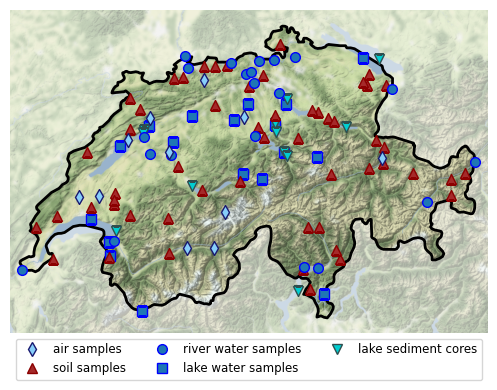

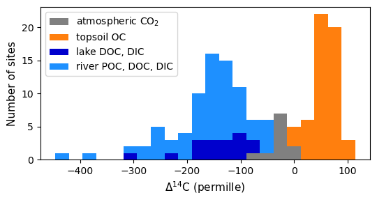

```python
fig, ax = RICH_data.plots.plot_Switzerland_map()
fig, ax = RICH_data.plots.plot_Switzerland_14C_histogram()
```

### Save plots

If you want to save a plot, do this:

```python
fig, ax = RICH_data.plots.plot_Switzerland_map(
    #save = '~/Desktop/plots/map_of_switzerland.png', # uncomment and edit this
    dpi = 300, # dots per inch, dpi = 500 by default
    show = False, # show the plot after saving, True by default
    close = True, # close the plot after saving and showing, True by default
)
```

Accepted file extensions include png, jpg, pdf, svg, ...

### Edit plots: the quick and dirty way

If you want to add something to a plot, you can use the returned `fig` and `ax` objects. Make sure to select `close=False` and `show=False` so that you receive an open `fig`.

In this example, we add the shape of the Alpine Rhine catchment to the map of Switzerland:

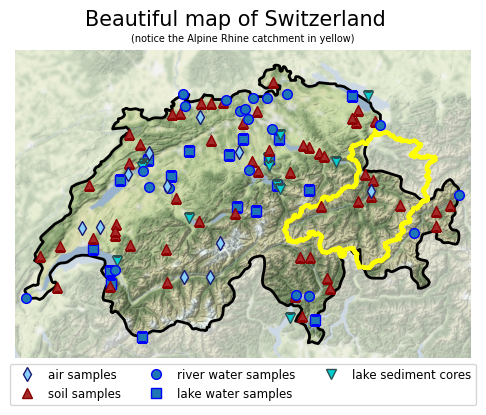

```python
import matplotlib.pyplot as plt
import cartopy.crs as ccrs

# Plot map of Switzerland without showing or closing
fig, ax = RICH_data.plots.plot_Switzerland_map(close=False, show=False)

# Read the shape data of NADUF catchments and select Diepoldsau station
catchments = RICH_data.NADUFShapeData().catchments
DI_catchment = catchments.set_index('station').loc['DI']

# Add outline of Alpine Rhine catchment above Diepoldsau to map
crs = ccrs.CRS(catchments.crs) # coordinate reference system
ax.add_geometries(DI_catchment.geometry, crs=crs, zorder=50,
                  facecolor='none', edgecolor='yellow', linewidth=3)

# Add title and show
plt.suptitle('Beautiful map of Switzerland', size=15)
plt.title('(notice the Alpine Rhine catchment in yellow)', size=7)
plt.show()
```

For any more substantial changes to the plots, you should probably write your own plot functions. Please contact me if you would like to contribute your own plots to the repository!

## Stay up to date

The `RICH_data` package is still in development and will be updated regularly with new datasets and bug fixes. To receive these updates from GitHub, run `git pull` from the RICH-data directory.